# Dublin Data Science El Dorado 2 Competition

Mick Cooney mickcooney@gmail.com

1 January 2019

# 1 Competition Summary

**Starting Date:** Now

**Closing Date:** TBD (early 2019 - most likely February)

There is gold in them-there hills!

In this competition the goal is to predict the amount of gold in an area and then win an auction for the rights to extract and sell the gold.

The winner of the competition is the team that finishes with the most cash after all bids and extraction costs are paid and the mined gold has been sold.

A dataset is being provided on which teams may base their predictions, and submissions for the competition take the form of bids for all the available parcels of land.

## 1.1 Quick Summary

- 5,000 data points with pseudo-geological information (including proven gold reserves).
- 50 (or more) new sites up for auction with limited data.
- Each team starts with $50,000,000.00 budget to bid with.
- Blind, sealed-bid auctions for rights to mine the parcel of land (min bid $100,000.00)
- Auctions happen in order by `parcel_id`.
- Extraction costs are non-trivial.
- Winning team is one with the most cash at the end of auctions.

# 2 Data Description

We have generated a random piece of land for which some basic data will be made available. This land is split up into a grid of 150x150 ‘parcels’. Elevation data is available for the entire grid.

5,000 squares were previously auctioned and exploited. Complete information for these parcels is available as part of the dataset.

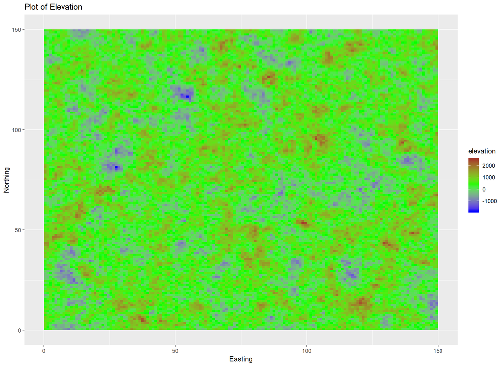

The ‘pseudo-geological’ information provided with the data is not based on reality, instead being made up by me arbitrarily (with some inspiration from the game Eve Online).

Geological compositions found in the ground are grouped into three categories: Mineral, Ore and Rock. Quantities within each category tend to co-occur though the exact nature of this relationship is unknown.

- **Minerals:** Isogen, Megacyte, Mexallon, Nocxium, Pyerite, Tritanium
- **Ore:** Gneiss, Hedbergite, Plagioclase, Spudumain, Veldspar
- **Rock:** Arkonor, Bistot, Crokite, Mercoxit

# 3 Competition Setup

Unlike other competitions involving predictive modeling, we are not providing any kind of ‘error metric’ for your predictions. This competition will not reward the most accurate predictions for the amount of gold in the parcels provided. Instead, this competition emphasises effective use of the predictions.

Participants will bid for parcels of land according to their perceived or predicted value and then make a profit or loss according to the amount of gold found in the parcels of land they win at auction.

The score for each team in this competition is the final cash balance after parcel bids are paid, the gold is extracted, extraction costs are paid and the extracted gold is sold.

Gold is priced in US Dollars (USD) and so this is currency of choice for this competition.

All auction bids, extraction expenses and gold amounts are priced in USD, and the final amount possessed by each team at the final accounting is their score.

## 3.1 Gold Extraction Details

Extracting gold from the ground comes with a cost, which need to be factored into the profit calculation.

Extraction costs comprise two parts: *fixed costs* and *variable costs*, both of which depend on the elevation of the ground from which the gold is being extracted.

### 3.1.1 Fixed Costs

Fixed costs depend on the elevation of the land only and represent various capital costs required to mine the land such as plant installation, legal costs, etc.

| Elevation Class | Elevation Range | Fixed Cost |
| --- | --- | --- |
| **Low Elevation** | *Elevation < 0m* | $4,000,000.00 |
| **Medium Elevation** | *0m < Elevation <= 500m* | $3,000,000.00 |
| **High Elevation** | *Elevation > 500m* | $8,000,000.00 |

### 3.1.2 Variable Costs

Variable costs depend on the elevation of the land but also vary as the amount of gold is extracted. As more gold is mined, economies of scale mean that the cost per unit of gold extracted is reduced to a lesser or greater extent.

There are three elevation bands for variable costs: ‘Less than 0m’, ‘0-700m’, and ‘greater than 700m’.

| Elevation Class | Elevation Range |
| --- | --- |
| **Low Elevation** | *Elevation < 0m* |
| **Medium Elevation** | *0m < Elevation <= 700m* |
| **High Elevation** | *Elevation > 700m* |

**Note that the elevation bands for fixed and variable costs differ**

The variable costs are displayed here in a table and this data is available for download. Should a parcel of land contain more gold, the variable costs will scale according to trends shown in the data.

Note that the variable costs do not include the fixed costs.

```
##     gold_amount        low        med       high
##  1:           0         $0         $0         $0
##  2:        2000   $964,000   $882,000   $768,000
##  3:        4000 $1,868,000 $1,734,000 $1,359,000
##  4:        6000 $2,729,000 $2,565,000 $1,861,000
##  5:        8000 $3,559,000 $3,380,000 $2,323,000
##  6:       10000 $4,368,000 $4,184,000 $2,771,000
##  7:       12000 $5,161,000 $4,981,000 $3,218,000
##  8:       14000 $5,945,000 $5,773,000 $3,670,000
##  9:       16000 $6,723,000 $6,562,000 $4,130,000
## 10:       18000 $7,498,000 $7,349,000 $4,598,000
## 11:       20000 $8,271,000 $8,135,000 $5,073,000
```

Note that these are estimates of the underlying cost functions which maps gold amounts to the variable cost of extracting that amount of gold at the respective elevation levels.

So, if the parcel of land has 13,000 ounces of gold and is at 600m (medium elevation for variable costs), we expect the variable extraction costs for all 13,000 ounces to be somewhere between $4.8 and $5.9 million.

# 4 Parcel Auction

Parcels are allocated by a blind, sealed-bid auction. Your bids will be your submission to the competition.

The auction mechanism is the *Vickrey Auction* ([Wikipedia Entry](https://en.wikipedia.org/wiki/Vickrey_auction)) so the highest bid for the parcel wins but pays the bid of the second highest bidder. This mechanism helps avoid gaming bids and incentivises bidders to bid the true perceived value of the parcel.

Once the competition is closed and all entries are received, the parcels of land will be sequentially auctioned off in order of their id.

A budget of $50,000,000 is allocated to each team for bidding purposes and the total amount spent by a team on their winning bids cannot exceed this total. Teams may make total bids in excess of this amount if they anticipate not winning auctions, but overspends are penalised according to the rules below.

## 4.1 Example Auction

To illustrate the mechanics of the auction, we illustrate a simple one. Suppose we have five bids for a parcel of land with values:

- A - $1,500,000.00
- B - $1,200,000.00
- C - $1,000,000.00
- D - $1,000,000.00
- E - $800,000.00

In this case, Team A wins the auction with their bid of $1,500,000.00. As the second bid was $1,200,000, Team A pays this amount to secure the rights for that parcel of land.

Suppose this auction is one of the later ones and Team A only has $1,000,000 left to spend. Without the cash to pay for the parcel, Team A is removed from the auction and it is redone. In this case, Team B wins the auction and pays the new-second-highest bid: $1,000,000.00.

When the final scores are tallied, a fine of $100,000 is assessed on Team A’s score at the end.

# 5 Competition Rules

1. A competition signup sheet will be published a few days after the competition goes live. Signups will have a team name and an email address for contact details. Any and all correspondance for this competition will be done via that email address.
2. This competition is just for fun so there are no prizes beyond some kudos from me and the rest of the community. That said, if groups of you decide to form small pools amongst yourselves, let me know. It may be possible to accommodate such arrangements in an informal way.
3. It is expected that Dublin R will run a ‘Data Dojo’-style event after the competition concludes where participants will be invited to speak about the methods they employed. Participation in any such events is entirely optional but is always interesting and a lot of fun!
4. All quantities of gold in the competition are in ounces.
5. It is assumed that all teams have hedged the future price of gold at $1,500 per ounce. This is the price at which profits will be calculated.
6. If we have a larger than anticipated interest, I reserve the right to release additional parcels of land for auction, so that all entrants feel they have a shot at winning at least one parcel of land. Should this happen, all signed up participants will be informed via email and the datasets on the website will be updated.
7. Entries consist of a single CSV file with two columns: `parcel_id` (integer) and `bid_amount` (floating point with 2 decimal places).
8. All bid submissions should be send via email to the address `dublindatascience AT gmail`.
9. The minimum bid amount for each parcel of land is $100,000 USD. Bids below that amount will be considered 0.
10. Teams do not have to make a bid for every available parcel of land.
11. Not all parcels of land are guaranteed to make a profit - especially once bids are paid.
12. In the unlikely event of two winning bids being equal, the winner for that auction will be the team with the earlier timestamp on their submission. Please note that this means that they will pay the amount they bid, as the second-highest bid amount is the same amount!
13. Auctions are resolved in order of ‘parcel_id’ and are performed sequentially right at the start of the resolution process.
14. If, for whatever reason, a team is unable to pay an otherwise-winning bid, that team will be removed from the current auction, the auction will be redone without that team’s participation and a penalty of $100,000 will be assessed to the final score for the team (but not while the auctions are being determined). The team will still participate in subsequent auctions. Note that this means should that team fail to fund another winning bid, further fines will be assessed to their final score.
15. Fixed and variable costs for gold extraction are not paid out of the budget. It is assumed that money is paid out of the expected gold sales and are accounted at the end.
16. The top 5 scores will be published after the close of the competition so that those competitors may be lauded for their predictive prowess, the auction acumen and their overall level of general awesome. Other participants may also get their scores upon request.
17. Code for the auction will be made publicly available after completion of the competition. The data-generation code may be made available, though I may decide to keep it private in order to run future competitions with a similar structure.
18. If any of the rules appear unclear, first re-read them just in case. If you are still confused, drop me a mail at `mickcooney AT gmail`
19. I, Mick Cooney, hereby declare myself “El Dorado Competition Dictator-for-Life”. While not a cruel man, I do consider myself more a member of the Augustus Caesar / Sulla academy, and not so much the Julius Caesar one.
20. Anyone misbehaving or generally trying to cheat in some way will fall afoul of the above Dictator-for-Life clause. This is for fun, so whatever you are thinking of doing - just don’t. :)

# 6 Data Downloads

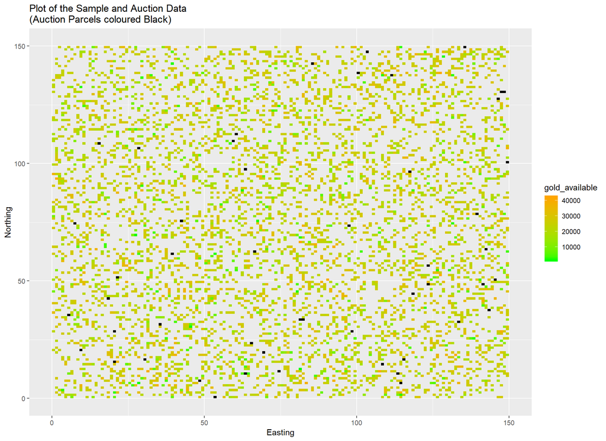

```r
head(sample_data_dt)
```

```
##    parcel_id Easting Northing  Pyerite Mexallon Tritanium Megacyte Nocxium
## 1:         5     4.5      0.5 109.7883 104.1234   119.108  99.3452 109.929
## 2:         7     6.5      0.5 125.9232 100.8622   101.869  99.2692 107.128
## 3:        12    11.5      0.5  95.1185 168.3372   144.466 131.3736 109.085
## 4:        14    13.5      0.5 102.7014 119.2452   125.239 118.4265 104.868
## 5:        19    18.5      0.5 105.8670 115.6214   124.467 106.7176 111.945
## 6:        21    20.5      0.5 109.0403  95.9246   113.966 137.6765 112.699
##     Isogen Veldspar Plagioclase Hedbergite Spudumain   Gneiss Arkonor Mercoxit
## 1: 111.561  95.1421      99.169    95.8237   96.7492  95.9176 109.370  98.4508
## 2: 111.277  89.9376     101.655   113.9645  110.3841 101.5063 114.613 112.2867
## 3: 115.988 129.0295     102.382   126.4824  121.4794 123.9715 122.736 116.1226
## 4: 110.223 110.2680     123.621   160.2960  124.1457  98.9621 103.126  98.0552
## 5: 129.352 153.6627     103.953   136.3955  163.2473 165.6170 110.295 103.5135
## 6: 110.745  99.0348     115.373   141.8846  141.6138 119.7545 111.270 106.4248
##     Bistot Crokite gold_available
## 1: 111.800 108.078       22265.86
## 2: 109.621 113.343       10225.27
## 3: 107.643 115.336       23143.65
## 4: 115.592 115.633       13107.51
## 5: 117.667 116.229       28950.78
## 6: 110.489 106.008        6697.46
```

```r
head(auction_data_dt)
```

```
##    parcel_id Easting Northing elevation Arkonor Mercoxit  Bistot Crokite
## 1:        54    53.5      0.5   748.731 107.518  101.800 136.366 119.547
## 2:      1015   114.5      6.5   833.652 112.001  113.230 114.542 104.775
## 3:      1099    48.5      7.5   968.028 118.715  114.981 106.866 107.953
## 4:      1564    63.5     10.5   965.228 125.449  133.993 127.277 109.121
## 5:      1614   113.5     10.5   658.741 105.176  103.548 104.995 105.513
## 6:      1725    74.5     11.5  -289.317 101.147  100.578 111.231 104.509
```

All the files available for this competition are available in a single zip file.

The datafile is downloadable here

The zip file contains the following files:

- **auction_parcels.csv**: This file contains the basic data available for the parcels of land available for auction.
- **costs_data.csv**: This file gives estimations for the variable costs for extracting the gold.
- **elevation_data.csv**: This file contains the elevation data for the full 150x150 grid of parcels.
- **sample_data.csv**: This is the training data supplied to all the participating teams.